# Exercise 5

Niclas Simmler

27.03.20

# Exercise 5.1

Simulations are key to validate models. Thus, we would like to use this exercise to simulate several time series by means of an ARMA model.

## a) & b)

AR(2) model with coefficients $\alpha_1 = 0.9$ and $\alpha_2 = −0.5$. MA(3) model with coefficients $\beta_1 = 0.8$, $\beta_2 = −0.5$ and $\beta_3 = −0.4$.

```r
sim.coef.a <- c(0.9, -0.5)
sim.coef.b <- c(0.8, -0.5, -0.4)
```

### i)

First think of how the autocorrelations should behave theoretically.

### ii)

Use the procedure ARMAacf() to compute the theoretical autocorrelations of the models and plot them.

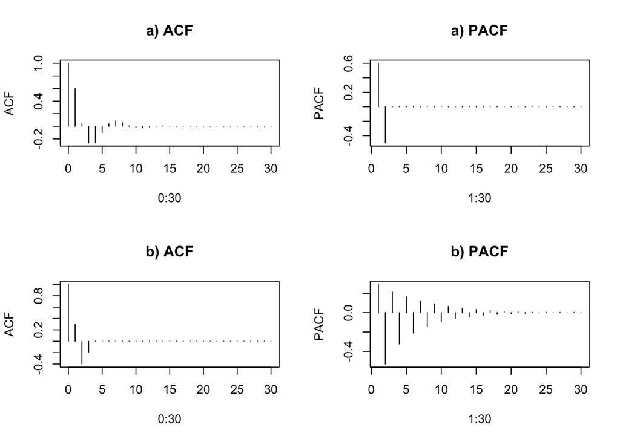

```r
par(mfrow=c(2,2))
plot(0:30, ARMAacf(ar = sim.coef.a, lag.max = 30), type = "h", ylab = "ACF", main = 'a) ACF')
plot(1:30, ARMAacf(ar = sim.coef.a, lag.max = 30, pacf = TRUE), type = "h", ylab = "PACF", main = 'a) PACF')
plot(0:30, ARMAacf(ma = sim.coef.b, lag.max = 30), type = "h", ylab = "ACF", main = 'b) ACF')
plot(1:30, ARMAacf(ma = sim.coef.b, lag.max = 30, pacf = TRUE), type = "h", ylab = "PACF", main = 'b) PACF')
```

1. Interestingly, the ACF suggests some seasonality (damped sigmoid) in the data.
2. The PACF shows correlation past lag 3.

## iii)

Now simulate a realisation of length $n = 200$ for the models a) - c). Repeat each simulation several times to develop some intuition on what occurs by chance and what is structure.

```r
sim.data.a <- arima.sim(list(ar=sim.coef.a), n=200)
sim.data.b <- arima.sim(list(ma=sim.coef.b), n=200)
```

## iv)

Inspect the time series plot and the correlograms with the ordinary and partial autocorrelations.

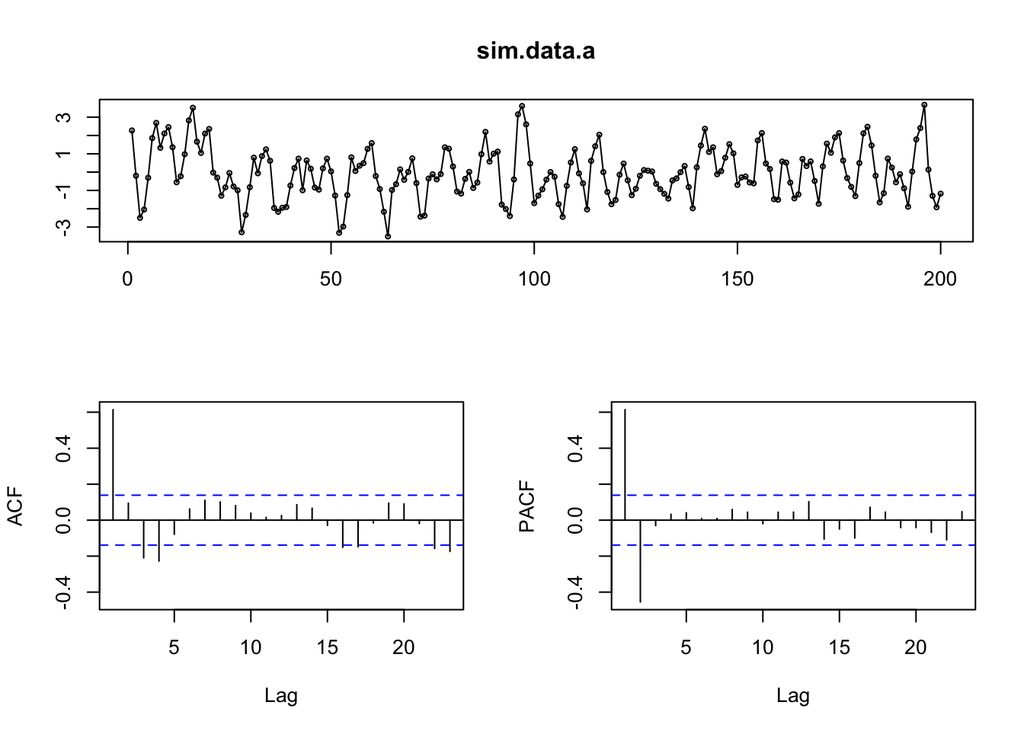

```r
library(forecast)
tsdisplay(sim.data.a)
```

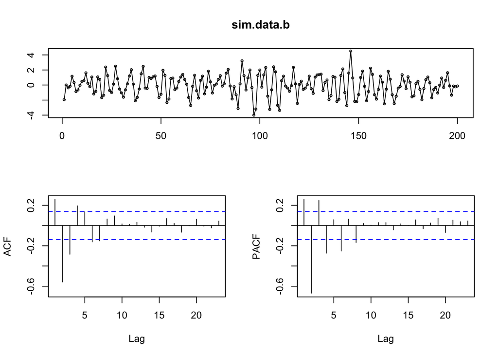

```r
tsdisplay(sim.data.b)
```

1. There is no obvious structure visible in the timeseries. The ACF plot suggests that the timeseries is NOT i.i.d (no random behavior).
2. There is no obvious structure visible in the timeseries. The ACF plot suggests that the timeseries is NOT i.i.d (no random behavior).

# Exercise 5.2

In this exercise we consider some examples of AR(p) models and check their stationarity.

## a)

Test the models

1. $X_t = 0.5X_{t-1} + 2X_{t-2} + \epsilon_t$
2. $Y_t = Y_{t-1} + \epsilon_t$

with the innovation Et on stationarity with the help of the R function polyroot.

*i)* Find Characteristic Polynom:

$\rightarrow X_t - 0.5X_{t-1} - 2X_{t-2} = \epsilon_t$

$\rightarrow (1 - 0.5B - 2B) X_t = \epsilon_t$

$\rightarrow \Phi(Z) = 1 - 0.5Z -2Z$

```r
coefs.i <- c(1, -0.5, -2)
abs(polyroot(coefs.i))
```

```
[1] 0.5930703 0.8430703
```

All absolute values of the coefficients are below 1, hence the timeseries is *not* stationary.

*ii)* Find Characteristic Polynom:

$\rightarrow Y_t - Y_{t-1} = \epsilon_t$

$\rightarrow (1 - B) Y_t = \epsilon_t$

$\rightarrow \Phi(Z) = 1 - Z$

```r
coefs.ii <- c(1, -1)
abs(polyroot(coefs.ii))
```

```
[1] 1
```

There is no coefficient strictly greater than 1, hence the timeseries is *not* stationary.

## b)

For which value of the coefficient $\alpha_2$ of $X_{t−2}$ is the model $X_t = 0.5X_{t-1} + \alpha X_{t-2} + \epsilon_t$ stationary?

```r
alphas <- c()
counter <- 1
for(alpha in -100:100){
  if(abs(polyroot(c(1,0.5,-((alpha/10))))) > 1){
    alphas[counter] <- (alpha/10)
    counter <- counter + 1
  }
}
alphas
```

```
 [1] -0.9 -0.8 -0.7 -0.6 -0.5 -0.4 -0.3 -0.2 -0.1  0.0  0.1  0.2  0.3  0.4  0.8
[16]  0.9  1.0  1.1  1.2  1.3  1.4
```

## c)

Why is the model $Y_t = \alpha Y_{t−1} + E_t$ not stationary for $\ |\alpha| \ge 1$? Calculate the characteristic function and determine its roots to confirm this observation.

The bigger the $\alpha$ the bigger the dependence on the previous timeseries step. This means stationarity cannot be achieved since timeseries steps should be as independent as possible.

```r
polyroots <- c()
for(alpha in 1:10){
  polyroots[alpha] <- abs(polyroot(c(1,-alpha)))
}
polyroots
```

```
 [1] 1.0000000 0.5000000 0.3333333 0.2500000 0.2000000 0.1666667 0.1428571
 [8] 0.1250000 0.1111111 0.1000000
```

The polyroots show, that the bigger $\alpha$ becomes, the smaller the root becomes (further away from 1). Hence, stationarity-likelyhood decreases.